# Transformations, Forecasting and Bias Correction

### Using the Residuals to Determine the Appropriate Correction

The residuals of this model are illustrated in Figure 9.

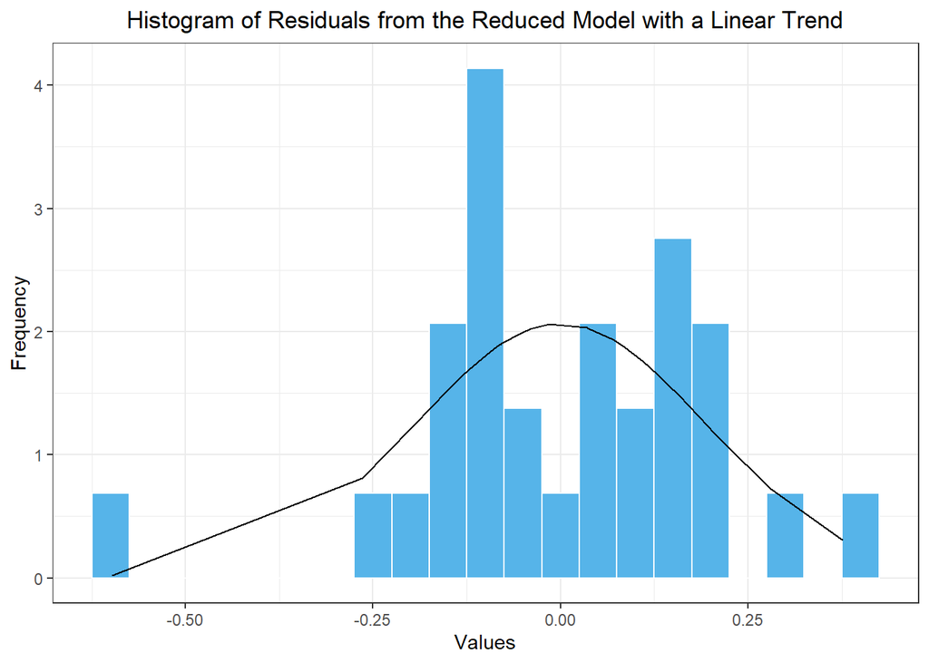

Figure 9: Histogram of the residuals from the reduced model with a linear trend component

```r
apple_resid_df <- model_combined |>
  dplyr::select(apple_linear) |>
  residuals() |>
  as_tibble() |>
  dplyr::select(.resid) |>
  rename(x = .resid)

apple_resid_df |>
  mutate(density = dnorm(x, mean(apple_resid_df$x), sd(apple_resid_df$x))) |>
  ggplot(aes(x = x)) +
    geom_histogram(aes(y = after_stat(density)),
        color = "white", fill = "#56B4E9", binwidth = 0.05) +
    geom_line(aes(x = x, y = density)) +
    theme_bw() +
    labs(
      x = "Values",
      y = "Frequency",
      title = "Histogram of Residuals from the Reduced Model with a Linear Trend"
    ) +
    theme(
      plot.title = element_text(hjust = 0.5)
    )
```

Using the command `skewness(apple_resid_df$x)`, we compute the skewness of these residuals as: -0.711. This number is not close to zero (it is between -1 and -0.5) indicating moderate skewness. We would therefore apply the empirical correction to our mean forecast values.

### Applying the Correction Factor

Table 3 summarizes some of the corrected mean values. Note that in this particular case, the corrected values are very close to the uncorrected values.

```r
apple_model_values <- model_combined |>
  dplyr::select(apple_linear) |>
  glance()

apple_model_check <- apple_model_values |>
  mutate(
    sigma = sqrt(sigma2),
    lognorm_cf = exp((1/2) * sigma2),
    empirical_cf = apple_linear_lm |>
      residuals() |>
      pull(.resid) |>
      exp() |>
      mean()) |>
  select(.model, r_squared, sigma2, sigma, lognorm_cf, empirical_cf)

apple_pred <- model_combined |>
  dplyr::select(apple_linear) |>
  forecast(new_data = apple_ts) |>
  mutate(.mean_correction = .mean * apple_model_check$empirical_cf) |>
  select(t, revenue_billions, .mean, .mean_correction)
```

```r
apple_pred <- model_combined |>
  dplyr::select(apple_linear) |>
  forecast(new_data = apple_ts) |>
  mutate(.mean_correction = .mean * apple_model_check$empirical_cf) |>
  select(t, revenue_billions, .mean, .mean_correction)
```

Table 3: Fitted values for the model representing Apple’s quarterly revenue

| t | .mean | .mean_correction |
| --- | --- | --- |
| 1 | 1.293 | 1.316 |
| 2 | 0.896 | 0.911 |
| 3 | 1.103 | 1.122 |
| 4 | 1.416 | 1.441 |
| ⋮ | ⋮ | ⋮ |
| 28 | 36.873 | 37.516 |
| 29 | 57.956 | 58.965 |

### Plotting the Fitted Values

These fitted values are illustrated in Figure 10.

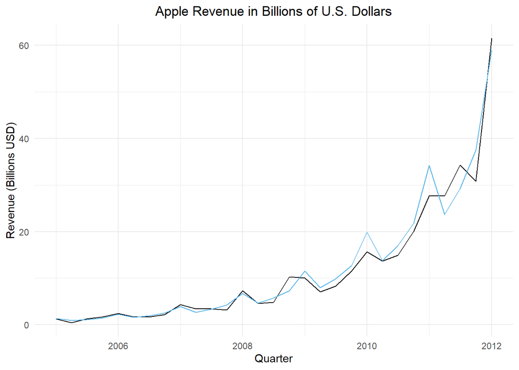

Figure 10: Apple Inc.’s quarterly revenue in billions of U.S. dollars through first quarter of 2012 (in black) and the fitted regression model (in blue)

```r
apple_ts |>
  autoplot(.vars = revenue_billions) +
  geom_line(data = apple_pred, aes(x = dates, y = .mean_correction), color = "#56B4E9") +
    labs(
      x = "Quarter",
      y = "Revenue (Billions USD)",
      title = "Apple Revenue in Billions of U.S. Dollars"
    ) +
    theme_minimal() +
    theme(plot.title = element_text(hjust = 0.5))
```

This time series was used as an example. We are obviously not interested in forecasting future values using this model. However, this is an excellent example of real-world exponential growth in a time series with a seasonal component. Limiting factors prevent exponential growth from being sustainable in the long run. After 2012, the Apple quarterly revenues follow a different, but very impressive, model. This is illustrated in Figure 11.

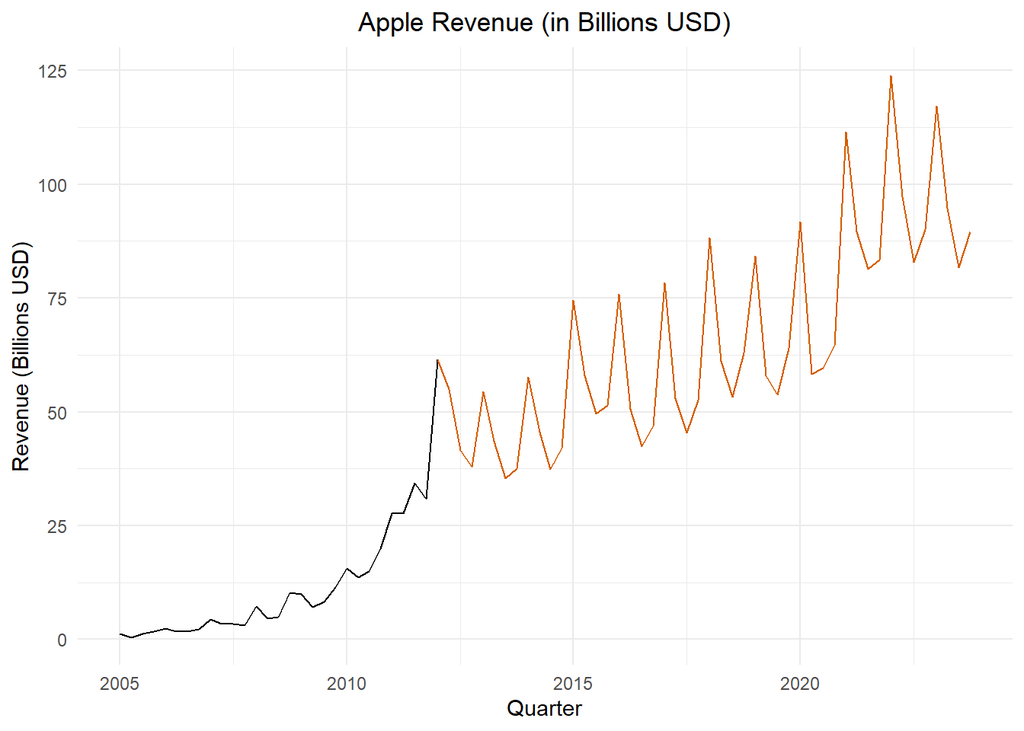

Figure 11: Apple Inc.’s quarterly revenue in billions of U.S. dollars; values beginning with the first quarter of 2012 are shown in orange

```r
apple_raw |>
  dplyr::select(dates, revenue_billions) |>
  as_tsibble(index = dates) |>
  autoplot(.vars = revenue_billions) +
  geom_line(
    data = apple_raw |> filter(dates >= my("Jan 2012")),
    aes(x = dates, y = revenue_billions),
    color = "#D55E00"
  ) +
  labs(
    x = "Quarter",
    y = "Revenue (Billions USD)",
    title = "Apple Revenue (in Billions USD)"
  ) +
  theme_minimal() +
  theme(plot.title = element_text(hjust = 0.5))
```

## Small-Group Activity: Industrial Electricity Consumption in Texas

These data represent the amount of electricity used each month for industrial applications in Texas.

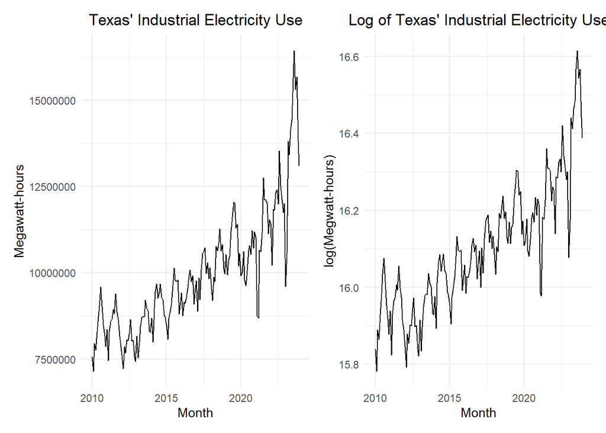

```r
elec_ts <- rio::import("https://byuistats.github.io/timeseries/data/electricity_tx.csv") |>
  dplyr::select(-comments) |>
  mutate(date = my(month),
         month = as.factor(month(date))) |>
  mutate(
    t = 1:n(),
    std_t = (t - mean(t)) / sd(t)
  ) |>
  as_tsibble(index = date)

elec_plot_raw <- elec_ts |>
    autoplot(.vars = megawatthours) +
    labs(
      x = "Month",
      y = "Megawatt-hours",
      title = "Texas' Industrial Electricity Use"
    ) +
    theme_minimal() +
    theme(
      plot.title = element_text(hjust = 0.5)
    )

elec_plot_log <- elec_ts |>
    autoplot(.vars = log(megawatthours)) +
    labs(
      x = "Month",
      y = "log(Megwatt-hours)",
      title = "Log of Texas' Industrial Electricity Use"
    ) +
    theme_minimal() +
    theme(
      plot.title = element_text(hjust = 0.5)
    )

elec_plot_raw | elec_plot_log
```

**TipCheck Your Understanding**

Use the Texas industrial electricity consumption data to do the following.

- Select an appropriate fitted model using the AIC, AICc, or BIC critera.
- Use the residuals to determine the appropriate correction for the data.
- Forecast the data for the next 5 years.
- Apply the appropriate correction to the forecasted values.
- Plot the fitted (forecasted) values along with the time series.

## Homework Preview (5 min)

- Review upcoming homework assignment
- Clarify questions

**NoteDownload Homework**

homework_5_2.qmd

Small-Group Activity

#### Small-Group Activity: Retail Sales Code

**CautionFigures**

```
Plot variable not specified, automatically selected `.vars = naics`
```

[figure not shown]

```r
# Read in retail sales data for "all other general merchandise stores"
retail_ts <- rio::import("https://byuistats.github.io/timeseries/data/retail_by_business_type.parquet") |>
  filter(naics == 45299) |>
  mutate(t = 1:n(),
         month = as.factor((t - 1) %% 12 + 1),
         month = factor(month, levels = 1:12, labels = month.abb)) |>
  mutate(std_t = (t - mean(t)) / sd(t)) |>
  as_tsibble(index = t)

autoplot(retail_ts)
```

Figure 13 shows the “All other general merchandise” retail sales data.

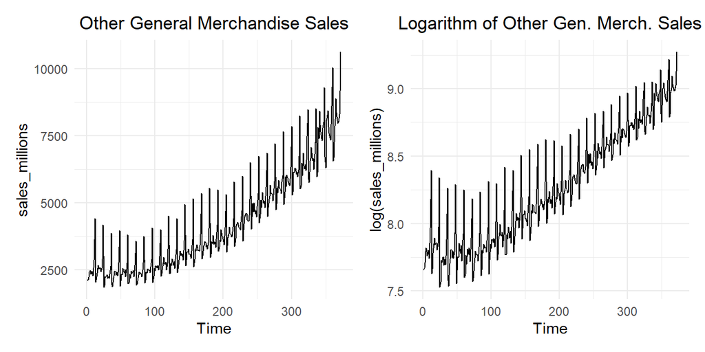

Figure 13: Time plot of the time series (left) and the natural logarithm of the time series (right)

```r
plot_raw <- retail_ts |>
    autoplot(.vars = sales_millions) +
    labs(
      x = "Time",
      y = "sales_millions",
      title = "Other General Merchandise Sales"
    ) +
    theme_minimal() +
    theme(
      plot.title = element_text(hjust = 0.5)
    )

plot_log <- retail_ts |>
    autoplot(.vars = log(sales_millions)) +
    labs(
      x = "Time",
      y = "log(sales_millions)",
      title = "Logarithm of Other Gen. Merch. Sales"
    ) +
    theme_minimal() +
    theme(
      plot.title = element_text(hjust = 0.5)
    )

plot_raw | plot_log
```

**CautionCubic Trend**

```r
# Cubic model with standardized time variable

cubic_lm <- retail_ts |>
  model(cubic = TSLM(log(sales_millions) ~ std_t + I(std_t^2) + I(std_t^3) + month)) # Note sin6 is omitted
cubic_lm |>
  tidy() |>
  select(!`.model`)|>
  mutate(sig = p.value < 0.05)
```

```
# A tibble: 15 × 6
   term        estimate std.error statistic   p.value sig
   <chr>          <dbl>     <dbl>     <dbl>     <dbl> <lgl>
 1 (Intercept)   8.01     0.00923    868.   0         TRUE
 2 std_t         0.469    0.00635     74.0  1.44e-218 TRUE
 3 I(std_t^2)    0.0715   0.00284     25.2  3.53e- 81 TRUE
 4 I(std_t^3)   -0.0419   0.00324    -12.9  1.45e- 31 TRUE
 5 monthFeb      0.0416   0.0124       3.35 8.99e-  4 TRUE
 6 monthMar      0.164    0.0124      13.2  1.34e- 32 TRUE
 7 monthApr      0.158    0.0124      12.7  6.73e- 31 TRUE
 8 monthMay      0.222    0.0124      17.9  1.37e- 51 TRUE
 9 monthJun      0.179    0.0124      14.4  1.39e- 37 TRUE
10 monthJul      0.155    0.0124      12.5  5.48e- 30 TRUE
11 monthAug      0.161    0.0124      13.0  8.86e- 32 TRUE
12 monthSep      0.113    0.0124       9.09 6.73e- 18 TRUE
13 monthOct      0.187    0.0124      15.1  5.51e- 40 TRUE
14 monthNov      0.284    0.0124      22.8  8.05e- 72 TRUE
15 monthDec      0.549    0.0124      44.2  8.72e-147 TRUE
```

**CautionQuadratic Trend**

```r
quad_lm <- retail_ts |>
  model(quad = TSLM(log(sales_millions) ~ std_t + I(std_t^2) +
    month )) # Note sin6 is omitted
quad_lm |>
  tidy() |>
  select(!`.model`)|>
  mutate(sig = p.value < 0.05)
```

```
# A tibble: 14 × 6
   term        estimate std.error statistic   p.value sig
   <chr>          <dbl>     <dbl>     <dbl>     <dbl> <lgl>
 1 (Intercept)   8.02     0.0112     718.   0         TRUE
 2 std_t         0.394    0.00307    128.   1.69e-301 TRUE
 3 I(std_t^2)    0.0715   0.00344     20.8  1.17e- 63 TRUE
 4 monthFeb      0.0411   0.0150       2.74 6.51e-  3 TRUE
 5 monthMar      0.163    0.0150      10.8  7.54e- 24 TRUE
 6 monthApr      0.157    0.0150      10.4  1.90e- 22 TRUE
 7 monthMay      0.220    0.0150      14.7  1.67e- 38 TRUE
 8 monthJun      0.177    0.0150      11.8  2.43e- 27 TRUE
 9 monthJul      0.152    0.0150      10.1  1.93e- 21 TRUE
10 monthAug      0.158    0.0150      10.5  1.10e- 22 TRUE
11 monthSep      0.109    0.0150       7.27 2.23e- 12 TRUE
12 monthOct      0.183    0.0150      12.2  9.60e- 29 TRUE
13 monthNov      0.279    0.0150      18.6  1.91e- 54 TRUE
14 monthDec      0.544    0.0150      36.2  1.02e-121 TRUE
```

**CautionLinear Trend**

```r
linear_lm <- retail_ts |>
  model(linear = TSLM(log(sales_millions) ~ std_t +month )) # Note sin6 is omitted
linear_lm |>
  tidy() |>
  select(!`.model`)|>
  mutate(sig = p.value < 0.05)
```

```
# A tibble: 13 × 6
   term        estimate std.error statistic   p.value sig
   <chr>          <dbl>     <dbl>     <dbl>     <dbl> <lgl>
 1 (Intercept)   8.09     0.0158     513.   0         TRUE
 2 std_t         0.394    0.00456     86.5  1.88e-242 TRUE
 3 monthFeb      0.0410   0.0223       1.84 6.65e-  2 FALSE
 4 monthMar      0.163    0.0223       7.29 1.97e- 12 TRUE
 5 monthApr      0.157    0.0223       7.02 1.09e- 11 TRUE
 6 monthMay      0.220    0.0223       9.87 1.67e- 20 TRUE
 7 monthJun      0.177    0.0223       7.93 2.75e- 14 TRUE
 8 monthJul      0.152    0.0223       6.83 3.71e- 11 TRUE
 9 monthAug      0.158    0.0223       7.07 8.25e- 12 TRUE
10 monthSep      0.109    0.0223       4.89 1.52e-  6 TRUE
11 monthOct      0.183    0.0223       8.19 4.66e- 15 TRUE
12 monthNov      0.279    0.0223      12.5  4.66e- 30 TRUE
13 monthDec      0.544    0.0223      24.4  3.80e- 78 TRUE
```

**CautionModel Comparison**

```r
model_combined <- retail_ts |>
  model(
    cubic = TSLM(log(sales_millions) ~ std_t + I(std_t^2) + I(std_t^3) + month),
    quadratic = TSLM(log(sales_millions) ~ std_t + I(std_t^2) + month),
    linear = TSLM(log(sales_millions) ~ std_t + month )
  )

glance(model_combined) |>
  select(.model, AIC, AICc, BIC)
```

Table 4: Comparison of the AIC, AICc, and BIC values for the models fitted to the logarithm of the retail sales time series.

| Model | AIC | AICc | BIC |
| --- | --- | --- | --- |
| cubic | **-2229.2** | **-2227.7** | **-2166.5** |
| quadratic | -2088.6 | -2087.3 | -2029.8 |
| linear | -1795.4 | -1794.3 | -1740.6 |

The model with the lowest AIC, AICc, and BIC values is the full cubic model.

**CautionAutocorrelation of the Random Component**

We check for autocorrelation in the random component to determine if using additional fitting is warranted.

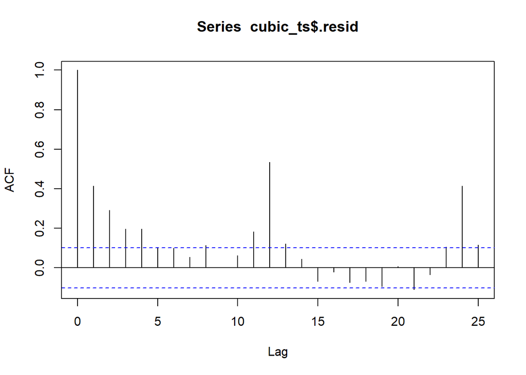

```r
cubic_ts <- cubic_lm |>
  residuals()

acf(cubic_ts$.resid, plot=TRUE, lag.max = 25)
```

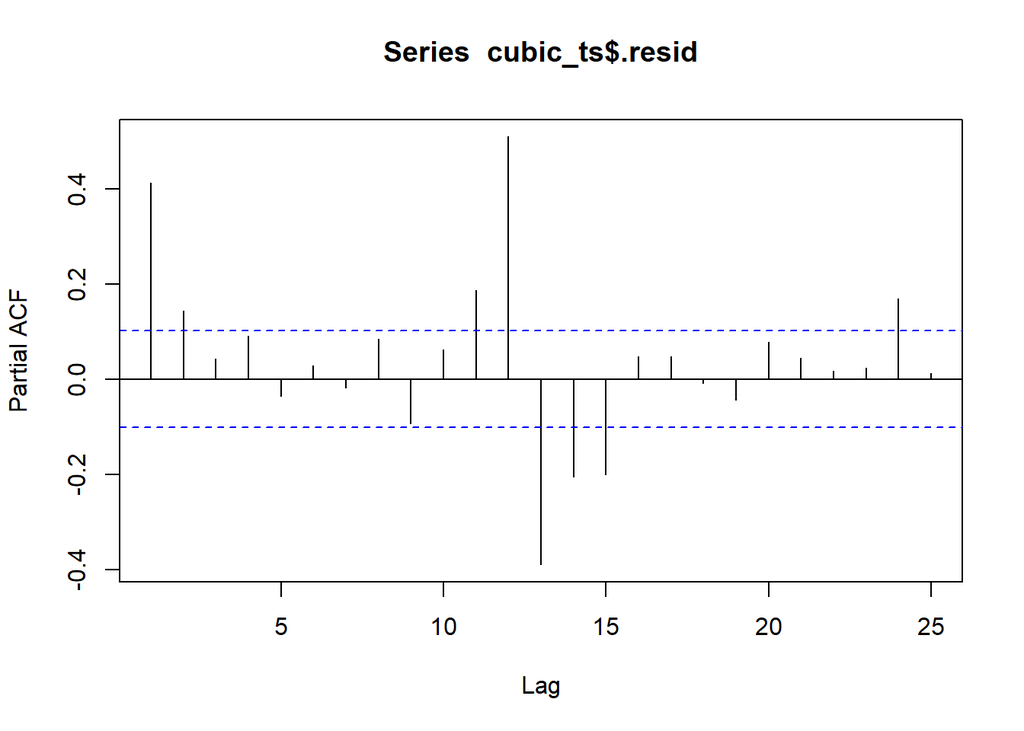

```r
alphas_quad <- pacf(cubic_ts$.resid, plot=FALSE, lag.max = 25)
pacf(cubic_ts$.resid, plot=TRUE, lag.max = 25)
```

**CautionApplying Autoregression, AR**

Recall that in [Chapter 5, Lesson 1](https://byuistats.github.io/timeseries/chapter_5_lesson_1.html#FittingRegModelWithPACF), we fitted a linear regression model using the value of the partial autocorrelation function for $k=2$. This helps account for the autocorrelation in the residuals.

```r
log_cube_ar <- retail_ts |>
  model(AR(log(sales_millions) ~ std_t + I(std_t^2) + I(std_t^3) + season(12) + order(2)))

tidy(log_cube_ar) |> select(!.model)
```

```r
tidy(log_cube_ar) |>
  select(!.model) |>
  mutate(
    # Pretty the month labels with regex and month.abb
    term = if_else(
      str_detect(term, "season"),          # IF the term label has "season" in it
      convert_season_label_to_month(term), # Make the label readable (function above)
      term                                 # ELSE keep the label as is
    ),
    lower = estimate + qnorm(0.025) * std.error,
    upper = estimate + qnorm(0.975) * std.error
  )
```

```
# A tibble: 17 × 7
   term       estimate std.error statistic   p.value   lower   upper
   <chr>         <dbl>     <dbl>     <dbl>     <dbl>   <dbl>   <dbl>
 1 constant     4.42     0.460        9.60 1.49e- 19  3.52    5.32
 2 std_t        0.235    0.0266       8.83 4.85e- 17  0.183   0.287
 3 I(std_t^2)   0.0345   0.00484      7.12 6.13e- 12  0.0250  0.0440
 4 I(std_t^3)  -0.0211   0.00371     -5.70 2.52e-  8 -0.0284 -0.0139
 5 Feb         -0.660    0.0168     -39.2  4.64e-131 -0.692  -0.627
 6 Mar         -0.458    0.0306     -15.0  1.34e- 39 -0.518  -0.398
 7 Apr         -0.272    0.0164     -16.5  5.35e- 46 -0.304  -0.240
 8 May         -0.327    0.0133     -24.6  1.02e- 78 -0.353  -0.301
 9 Jun         -0.278    0.0126     -22.2  5.95e- 69 -0.303  -0.254
10 Jul         -0.343    0.0113     -30.3  2.71e-100 -0.366  -0.321
11 Aug         -0.361    0.0127     -28.4  1.48e- 93 -0.386  -0.336
12 Sep         -0.341    0.0128     -26.7  6.46e- 87 -0.366  -0.316
13 Oct         -0.387    0.0124     -31.1  1.54e-103 -0.412  -0.363
14 Nov         -0.297    0.0138     -21.5  2.69e- 66 -0.324  -0.270
15 Dec         -0.220    0.0120     -18.3  3.20e- 53 -0.243  -0.196
16 ar1          0.358    0.0519       6.90 2.38e- 11  0.257   0.460
17 ar2          0.143    0.0519       2.76 6.10e-  3  0.0415  0.245
```

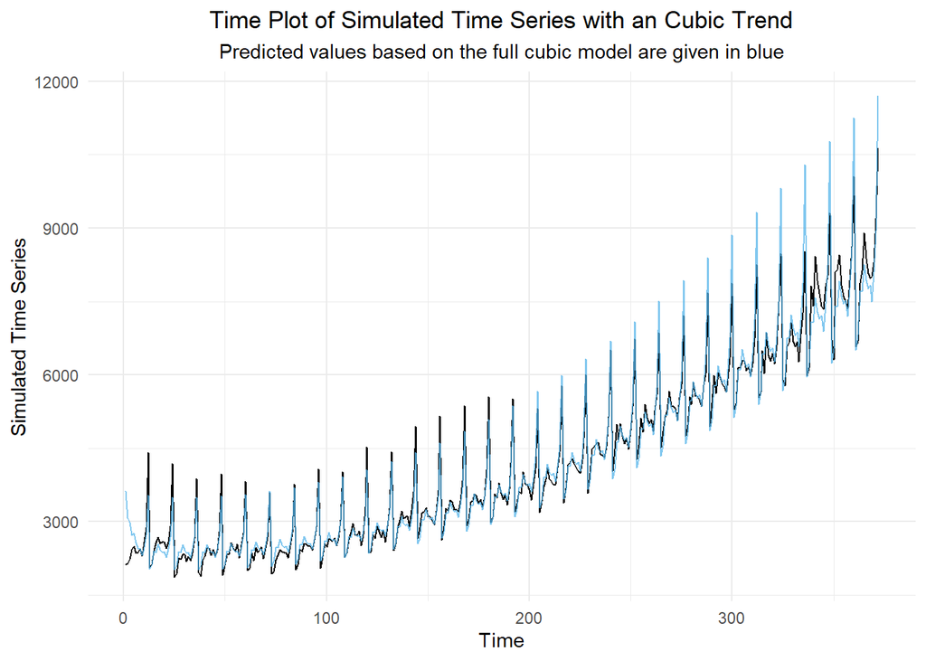

```r
forecast_df <- log_cube_ar |>
  forecast(retail_ts) |>  # computes the anti-log of the predicted values and returns them as .mean
  as_tibble() |>
  dplyr::select(std_t, .mean) |>
  rename(pred = .mean)

retail_ts |>
  left_join(forecast_df, by = "std_t") |>
  as_tsibble(index = t) |>
  autoplot(.vars = sales_millions) +
  geom_line(aes(y = pred), color = "#56B4E9", alpha = 0.75) +
    labs(
      x = "Time",
      y = "Simulated Time Series",
      title = "Time Plot of Simulated Time Series with an Cubic Trend",
      subtitle = "Predicted values based on the full cubic model are given in blue"
    ) +
    theme_minimal() +
    theme(
      plot.title = element_text(hjust = 0.5),
      plot.subtitle = element_text(hjust = 0.5)
    )
```

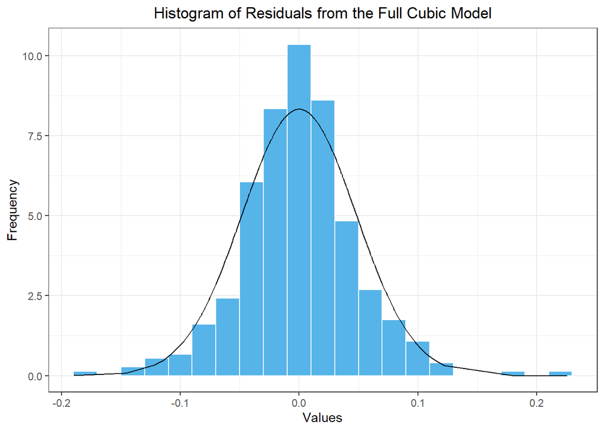

```r
retail_resid_df <-  cubic_lm |>
  residuals() |>
  as_tibble() |>
  dplyr::select(.resid) |>
  rename(x = .resid)

retail_resid_df |>
  mutate(density = dnorm(x, mean(retail_resid_df$x), sd(retail_resid_df$x))) |>
  ggplot(aes(x = x)) +
    geom_histogram(aes(y = after_stat(density)),
        color = "white", fill = "#56B4E9", binwidth = 0.02) +
    geom_line(aes(x = x, y = density)) +
    theme_bw() +
    labs(
      x = "Values",
      y = "Frequency",
      title = "Histogram of Residuals from the Full Cubic Model"
    ) +
    theme(
      plot.title = element_text(hjust = 0.5)
    )
```

```r
skewness(retail_resid_df$x)
```

```
[1] 0.1706905
```

## Small-Group Activity: Industrial Electricity Consumption in Texas Solution

**TipCheck Your Understanding**

Use the Texas industrial electricity consumption data to do the following.

- Select an appropriate fitted model using the AIC, AICc, or BIC critera.
- Use the residuals to determine the appropriate correction for the data.
- Forecast the data for the next 5 years.
- Apply the appropriate correction to the forecasted values.
- Plot the fitted (forecasted) values along with the time series.

```r
# Cubic model with standardized time variable

elec_cubic_lm <- elec_ts |>
  model(elec_cubic = TSLM(log(megawatthours) ~ std_t + I(std_t^2) + I(std_t^3) + month)) # Note sin6 is omitted
elec_cubic_lm |>
  tidy() |>
  mutate(sig = p.value < 0.05)
```

```
# A tibble: 15 × 7
   .model     term        estimate std.error statistic   p.value sig
   <chr>      <chr>          <dbl>     <dbl>     <dbl>     <dbl> <lgl>
 1 elec_cubic (Intercept) 16.0       0.0166    963.    2.68e-291 TRUE
 2 elec_cubic std_t        0.124     0.0115     10.8   1.19e- 20 TRUE
 3 elec_cubic I(std_t^2)   0.0313    0.00513     6.10  8.50e-  9 TRUE
 4 elec_cubic I(std_t^3)   0.0105    0.00589     1.79  7.55e-  2 FALSE
 5 elec_cubic month2      -0.0711    0.0223     -3.18  1.78e-  3 TRUE
 6 elec_cubic month3       0.0169    0.0223      0.755 4.52e-  1 FALSE
 7 elec_cubic month4       0.0235    0.0223      1.05  2.95e-  1 FALSE
 8 elec_cubic month5       0.0594    0.0223      2.66  8.71e-  3 TRUE
 9 elec_cubic month6       0.0792    0.0224      3.54  5.26e-  4 TRUE
10 elec_cubic month7       0.110     0.0224      4.93  2.11e-  6 TRUE
11 elec_cubic month8       0.134     0.0224      6.00  1.37e-  8 TRUE
12 elec_cubic month9       0.0833    0.0224      3.72  2.79e-  4 TRUE
13 elec_cubic month10      0.0819    0.0224      3.66  3.51e-  4 TRUE
14 elec_cubic month11      0.00932   0.0224      0.416 6.78e-  1 FALSE
15 elec_cubic month12      0.0107    0.0224      0.478 6.33e-  1 FALSE
```

```r
# Quadratic model with standardized time variable

elec_quadratic_lm <- elec_ts |>
  model(elec_cubic = TSLM(log(megawatthours) ~ std_t + I(std_t^2) + month)) # Note sin6 is omitted
elec_quadratic_lm |>
  tidy() |>
  mutate(sig = p.value < 0.05)
```

```
# A tibble: 14 × 7
   .model     term        estimate std.error statistic   p.value sig
   <chr>      <chr>          <dbl>     <dbl>     <dbl>     <dbl> <lgl>
 1 elec_cubic (Intercept)  16.0      0.0167    957.    1.43e-292 TRUE
 2 elec_cubic std_t         0.143    0.00462    31.0   5.06e- 68 TRUE
 3 elec_cubic I(std_t^2)    0.0313   0.00517     6.05  1.04e-  8 TRUE
 4 elec_cubic month2       -0.0708   0.0225     -3.15  1.98e-  3 TRUE
 5 elec_cubic month3        0.0174   0.0225      0.773 4.41e-  1 FALSE
 6 elec_cubic month4        0.0242   0.0225      1.08  2.83e-  1 FALSE
 7 elec_cubic month5        0.0604   0.0225      2.69  8.03e-  3 TRUE
 8 elec_cubic month6        0.0805   0.0225      3.58  4.65e-  4 TRUE
 9 elec_cubic month7        0.112    0.0225      4.97  1.77e-  6 TRUE
10 elec_cubic month8        0.136    0.0225      6.04  1.09e-  8 TRUE
11 elec_cubic month9        0.0853   0.0225      3.79  2.15e-  4 TRUE
12 elec_cubic month10       0.0842   0.0225      3.74  2.58e-  4 TRUE
13 elec_cubic month11       0.0119   0.0225      0.529 5.98e-  1 FALSE
14 elec_cubic month12       0.0136   0.0225      0.603 5.48e-  1 FALSE
```

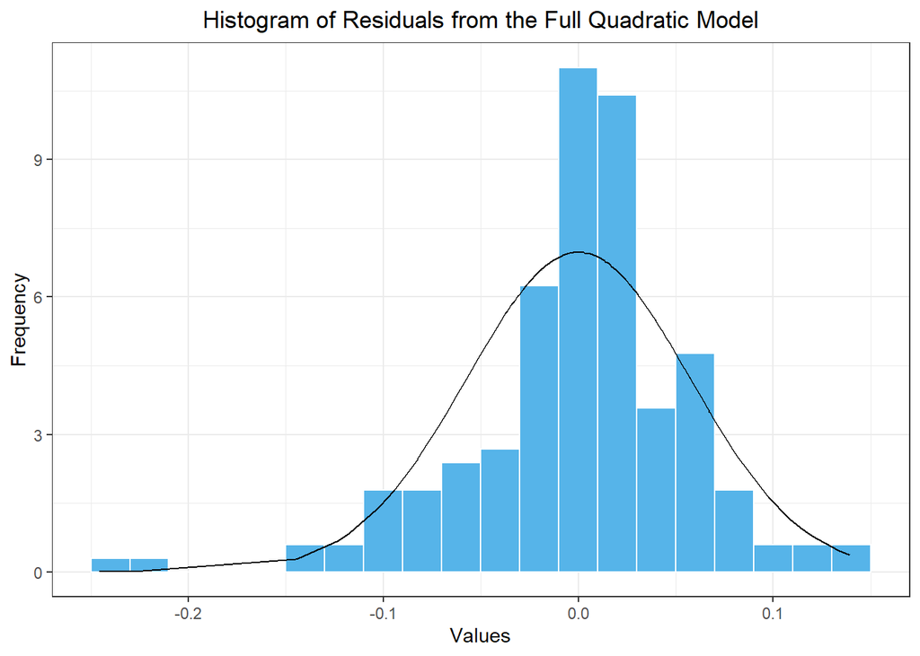

```r
elec_resid_df <- elec_quadratic_lm |>
  residuals() |>
  as_tibble() |>
  dplyr::select(.resid) |>
  rename(x = .resid)

elec_resid_df |>
  mutate(density = dnorm(x, mean(elec_resid_df$x), sd(elec_resid_df$x))) |>
  ggplot(aes(x = x)) +
    geom_histogram(aes(y = after_stat(density)),
        color = "white", fill = "#56B4E9", binwidth = 0.02) +
    geom_line(aes(x = x, y = density)) +
    theme_bw() +
    labs(
      x = "Values",
      y = "Frequency",
      title = "Histogram of Residuals from the Full Quadratic Model"
    ) +
    theme(
      plot.title = element_text(hjust = 0.5)
    )
```

```r
skewness(elec_resid_df$x)
```

```
[1] -0.9556189
```